# Analysis of Jail Populations in the US

Jaime Yang Li (jaimel3@uw.edu)

Autumn 2022

## Abstract

This project aims to expose patterns of injustice in the US justice system using data from the Vera Institute of Justice, a non-profit organization that works closely with the government and civil leaders to improve the justice system.

## Introduction

Vera’s data collection tool *Incarceration Trends data tool* was released in December of 2015 with the intent of challenging power regarding those incarcerated in America. The project aims to expose injustice in the justice system through accurate data collection and analysis. Vera challenges the usual method of data collection in the justice system by collecting data down to the county level, instead of the usual state or country level. While national data is important for a holistic view of the justice system, this detailed data allows us to identify and analyze regional biases. This individuals in this data are categorized by factors such as race, age, sex, and more. These values are available for most US counties. County data is categorized by features such as size, total population, region, and more.

This data extends to a vast amount of shareholders. This data is of great use to organizations dedicated to social justice (such as the NAACP) because it can be used to persuade those in power to reevaluate the current justice system and remove harmful legal programs, such as low-level drug charges. This data also shines a spotlight on regional issues regarding unbalanced incarceration rates that would otherwise by ignored by state-level data; it showcases the individuals associated with the data better.

The questions outlined in this report include: 1) Are some races incarcerated at higher levels, and to what extent?, 2) Are some regions more prone to incarceration, and what are the possible reasons?, and 3) How does state county level data look different from state data, and why?

## Data Summary

From the data set, one important feature we can observe is the racial demographic of incarcerated people. For example, the percentage of incarcerated people who were black in 2016 is 38.73%. By comparing this number to the actual percentage of black people in the US in 2016 reveals that the percentage of incarcerated black people is significantly higher than the percentage population in the entire US. This reveals a systematic bias against black individuals. Further analysis of different racial groups may reveal further biases.

Another data point I extracted from the data set is the average number of incarcerated people per county, which was 456.7 people per county (with sufficient data) in 2016. Using this value, we can detect regions with an “unusual” number of detainees and look further into why these regions have differing numbers. Some examples could be harsher state laws, harsher sentences, racial demographics, etc.

### **Graph 1:** Bar Chart of Jail Population in the U.S. over time

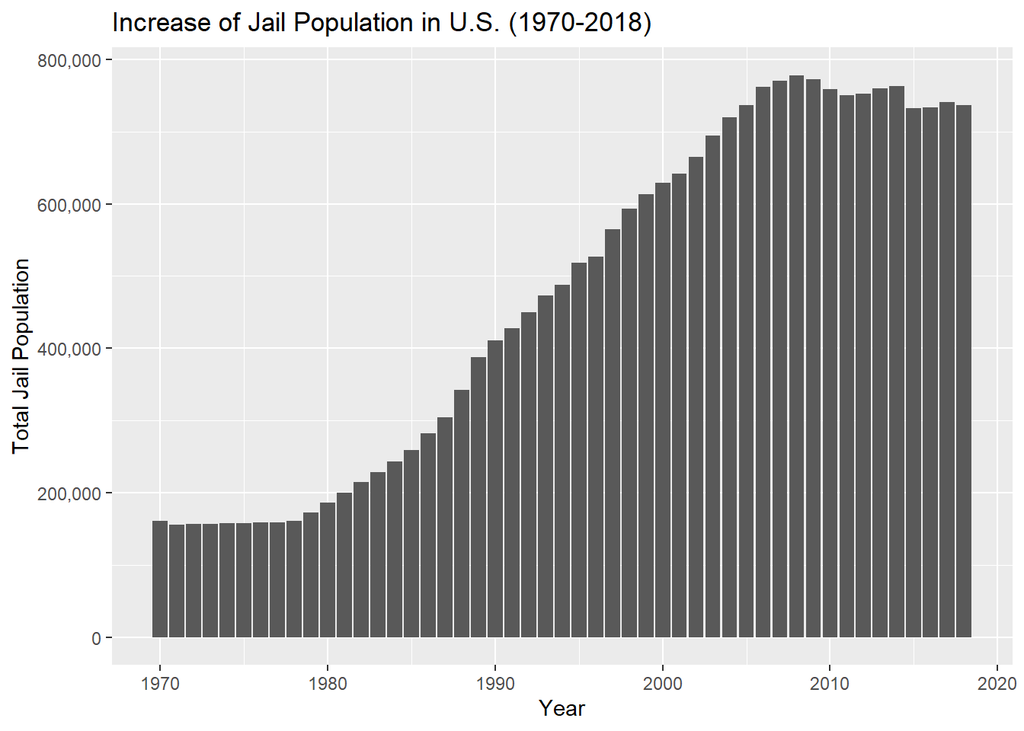

*Figure 1: Bar chart showing the increase in the US jail population from 1970 to 2018*

**How has the US jail population changed from 1970 to 2018?**

Graph 1 shows that the number of incarcerated people increased rapidly in the 1990’s and has plateaued. This dramatic increase of incarcerated people may coincide with the War on Drugs or other historical events in the US. A boom in population could also be a contributor to this increase. This data is important for understanding the US justice system on a holistic view.

### **Graph 2:** Line Plot of Jail Population Over Time in Four States

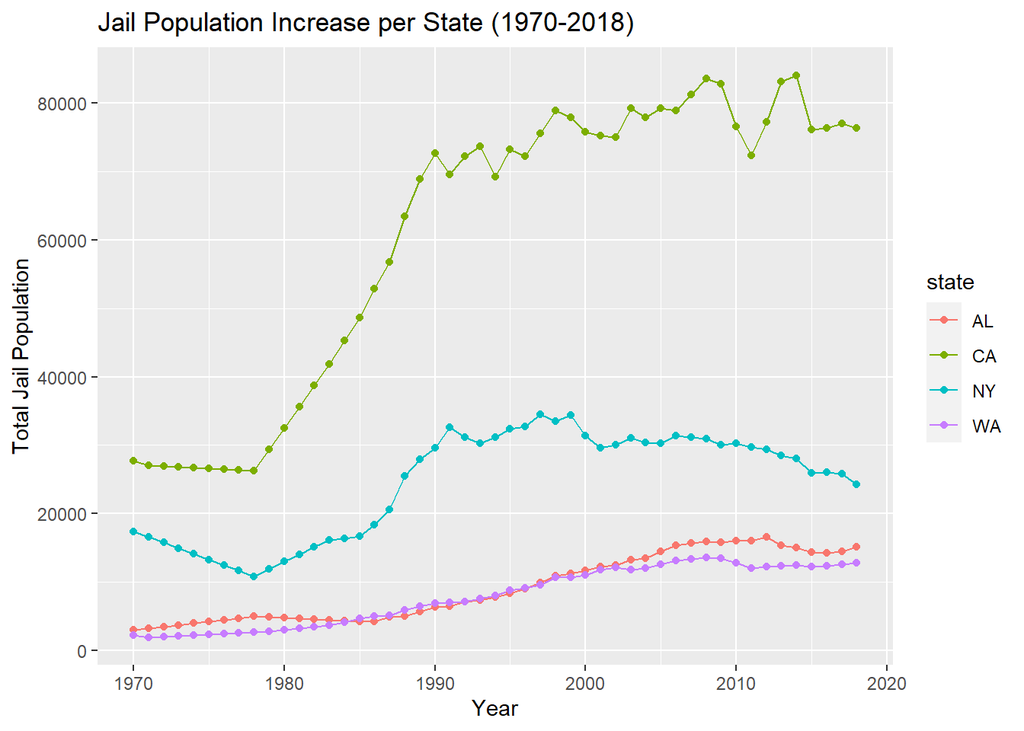

*Figure 2: Line graph showing the increase in jail populations from 1970 to 2018 for WA, CA, AL, and NY*

**How does state county level data look different from national data?**

Graph 2 shows the jail populations for California, Washington, Alabama, and New York. These states were chosen for their differing population sizes and locations. California has a consistently higher number of incarcerated people, as well as a higher increase in jail populations seen in the 1980s. This may be because of the War on Drug’s disproportionate impact on states and regions with higher Black and Hispanic populations. California’s high overall population and Black and Hispanic communities all contribute to its significantly higher prison population.

### **Graph 3:** Scatter Plot of Black Population vs Black Jail Population

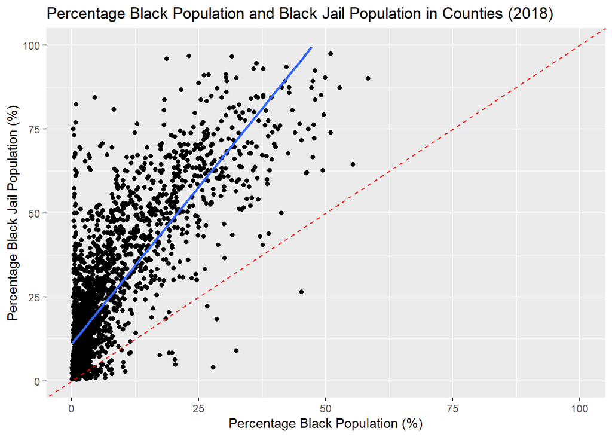

*Figure 3: Scatter plot comparing percentage Black population to percentage Black incarceration. (red dashed line represents the expected, “unbiased” trend line, blue line is the actual trend line)*

**Are some races incarcerated at higher levels, and to what extent?**

### **Graph 4.1 and 4.2:** Maps of Texas Incarceration Percentage and Totals (per county)

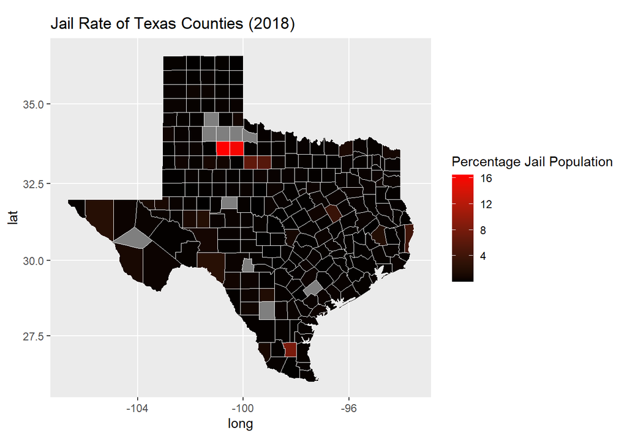

*Figure 4.1: Map showing the percentage of incarcerated people in Texas counties (2018)*

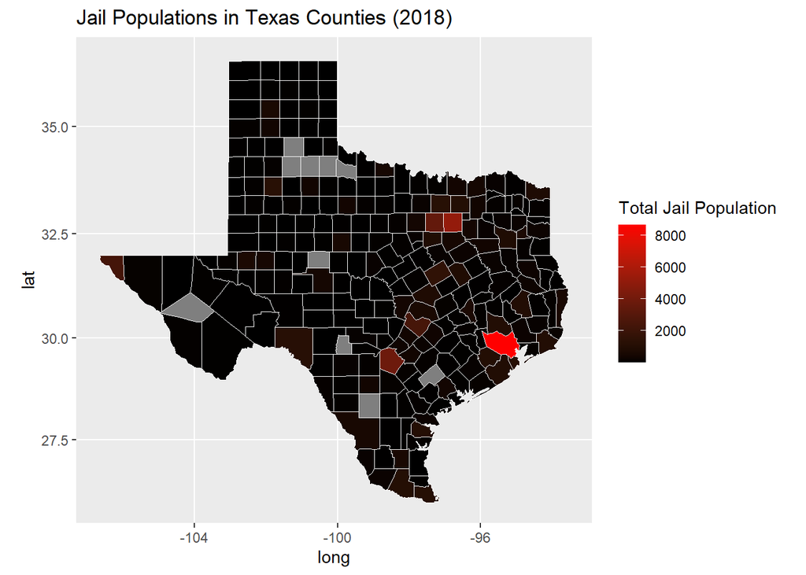

*Figure 4.2: Map showing the total of incarcerated people in Texas counties (2018)*

**How does state county level data look different from state data, and why?**

Texas’s data was chosen because of the state’s size and large population. The first map shows the percentage of citizens that are incarcerated and the second shows the number of incarcerated individuals. The purpose of the first map is to consider population size when it comes to incarceration numbers. By looking at the second map, we can see some counties with significantly higher imprisonment numbers, but that does not consider the fact that many counties have a much higher population density. There are some counties in the first map that have significantly higher incarceration rates. These rates should be looked into further and be compared to the county’s demographics.